# Lab 8 Introduction to Computational Finance

# task 1 Loading in your data set

- Load the working environment that contains the data set with the help of load().
- Use head() and tail() to explore the returns_df data set.
- The code chunks to create the timeplots of stocks on separate charts or within the same graph are provided. Make sure to have a close look at these.

```r
# Load the relevant packages
library("zoo")
# Load the working environment
load(url("http://s3.amazonaws.com/assets.datacamp.com/course/compfin/lab9.RData"))
# Explore the data set
head(returns_df)
```

```
##               Boeing    Nordstrom    Starbucks   Microsoft
## Mar 1995  0.15298607 -0.036153005  0.005213567 0.121301354
## Apr 1995  0.02299286 -0.056796794 -0.021053409 0.139234622
## May 1995  0.06808216  0.078207541  0.212444821 0.035293766
## Jun 1995  0.06174698 -0.003016273  0.203596782 0.065005425
## Jul 1995  0.06752700 -0.027569065  0.047965358 0.001379957
## Aug 1995 -0.04580883  0.027675498  0.067872071 0.021858794
```

```r
tail(returns_df)
```

```
##                Boeing   Nordstrom   Starbucks   Microsoft
## Aug 1999  0.001665287 -0.10216616 -0.01626052  0.07571941
## Sep 1999 -0.061141114 -0.04746691  0.08004069 -0.02184387
## Oct 1999  0.077557988 -0.07946425  0.09267201  0.02184387
## Nov 1999 -0.122442331  0.11217318 -0.02325686 -0.01650933
## Dec 1999  0.019801998 -0.05544145 -0.09108383  0.24866014
## Jan 2000  0.071301969 -0.17900166  0.27731929 -0.17634374
```

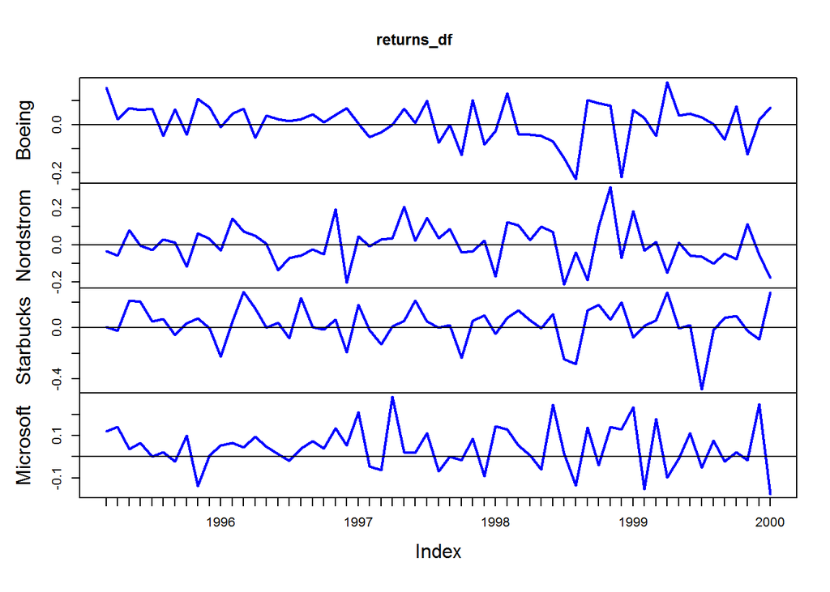

```r
# Timeplots of stocks on seperate graphs
my.panel <- function(...) {
  lines(...)
  abline(h=0)
}
plot(returns_df, lwd=2, panel=my.panel, col="blue")
```

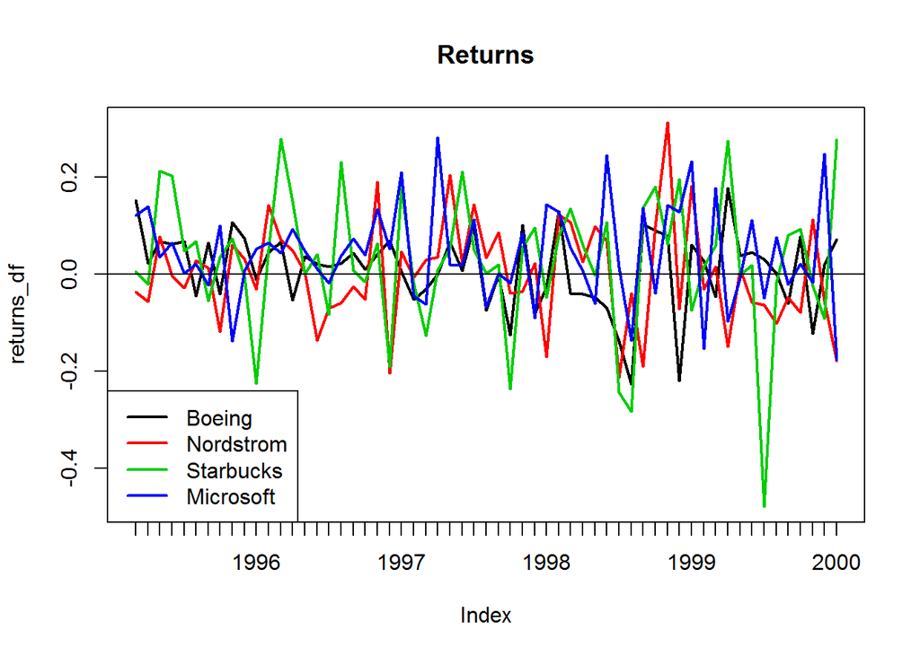

```r
# Timeplots of stocks on same graph
plot(returns_df, plot.type = "single", main="Returns", col=1:4, lwd=2)
abline(h=0)
legend(x="bottomleft", legend=colnames(returns_df), col=1:4, lwd=2)
```

# Task 2 The CER model

- Assign to sigma2_month the estimates of $\sigma^2_i$for all four assets.
- Calculate sigma_month, the estimates of $$\sigma_i$ for all four assets.
- Estimate the correlations $\rho_{ij}$ between all stocks, and assign the result to cor_mat_month.
- Create the pairwise scatterplots between all four stocks. Use coredata() to extract the core data from returns_df and pairs() to create a matrix of scatter plots. Take the color blue and use 16 for points pch.

```r
# All data is preloaded in your workspace.  Type 'ls()' in the console to see what has been loaded.

# Parameters CER model
mu_hat_month <- apply(returns_df, 2, mean)
mu_hat_month
```

```
##      Boeing   Nordstrom   Starbucks   Microsoft
## 0.011300419 0.001545065 0.028460847 0.042711830
```

```r
sigma2_month <- apply(returns_df, 2, var)

sigma2_month
```

```
##      Boeing   Nordstrom   Starbucks   Microsoft
## 0.006475909 0.011120975 0.020212207 0.010122211
```

```r
sigma_month <- sigma2_month^0.5

sigma_month
```

```
##     Boeing  Nordstrom  Starbucks  Microsoft
## 0.08047303 0.10545603 0.14216964 0.10060920
```

```r
cov_mat_month <- var(returns_df)
cov_mat_month
```

```
##                 Boeing    Nordstrom   Starbucks    Microsoft
## Boeing    0.0064759087 0.0008699794 0.003473484 0.0006925628
## Nordstrom 0.0008699794 0.0111209750 0.002636127 0.0018502818
## Starbucks 0.0034734841 0.0026361272 0.020212207 0.0011305061
## Microsoft 0.0006925628 0.0018502818 0.001130506 0.0101222108
```

```r
cor_mat_month <- cor(returns_df)

cor_mat_month
```

```
##               Boeing Nordstrom  Starbucks  Microsoft
## Boeing    1.00000000 0.1025149 0.30360442 0.08554037
## Nordstrom 0.10251495 1.0000000 0.17582801 0.17439288
## Starbucks 0.30360442 0.1758280 1.00000000 0.07903662
## Microsoft 0.08554037 0.1743929 0.07903662 1.00000000
```

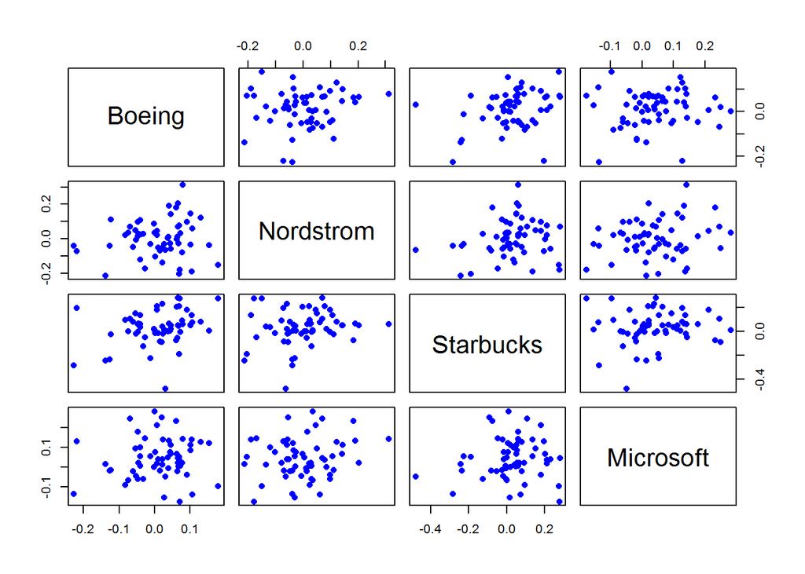

```r
# Pairwise scatterplots
pairs(coredata(returns_df), pch = 16, col = "blue")
```

# Task 3 The global minimum variance portfolio - Part One

- Use the globalMin.portfolio() function to calculate the global minimum variance portfolio here.
- Use plot() to visualize the weights of your four stocks in the global minimum variance portfolio.

```r
# All data and CER parameters are preloaded in your workspace.  Type 'ls()' in the console to see them.

# Calculate the global minimum variance portfolio
global_min_var_portfolio = globalMin.portfolio(er = mu_hat_month,
                    cov.mat = cov_mat_month,
                    shorts = T)


global_min_var_portfolio
```

```
## Call:
## globalMin.portfolio(er = mu_hat_month, cov.mat = cov_mat_month,
##     shorts = T)
##
## Portfolio expected return:     0.01846121
## Portfolio standard deviation:  0.05927073
## Portfolio weights:
##    Boeing Nordstrom Starbucks Microsoft
##    0.4562    0.2233    0.0512    0.2693
```

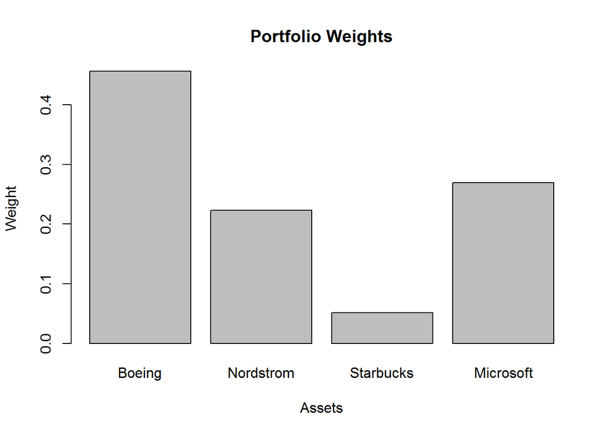

```r
# Plot the portfolio weights of our four stocks
plot(global_min_var_portfolio)
```

# Task 4 The global minimum variance portfolio - Part Two

- The restriction matrices are already set up. Make sure to study their output.
- Use these restriction matrices and the global minimum variance portfolio equality constraint to minimize the portfolio variance via solve.QP(). Assign the result to quad_prog.

```r
# All data and CER parameters are preloaded in your workspace.  Type 'ls()' in the console to see them.
library(quadprog)
# set restriction matrices
D_matrix <- 2* cov_mat_month
D_matrix
```

```
##                Boeing   Nordstrom   Starbucks   Microsoft
## Boeing    0.012951817 0.001739959 0.006946968 0.001385126
## Nordstrom 0.001739959 0.022241950 0.005272254 0.003700564
## Starbucks 0.006946968 0.005272254 0.040424414 0.002261012
## Microsoft 0.001385126 0.003700564 0.002261012 0.020244422
```

```r
d_vector <- rep(0,4)
d_vector
```

```
## [1] 0 0 0 0
```

```r
A_matrix <- cbind(rep(1,4),diag(4))
A_matrix
```

```
##      [,1] [,2] [,3] [,4] [,5]
## [1,]    1    1    0    0    0
## [2,]    1    0    1    0    0
## [3,]    1    0    0    1    0
## [4,]    1    0    0    0    1
```

```r
b_vector <- c(1,rep(0,4))
b_vector
```

```
## [1] 1 0 0 0 0
```

```r
# use solve.QP to minimize portfolio variance
quad_prog <- solve.QP(Dmat=D_matrix,
                      dvec=d_vector,
                      Amat=A_matrix,
                      bvec=b_vector,
                      meq=1)

quad_prog
```

```
## $solution
## [1] 0.45620455 0.22325180 0.05122725 0.26931639
##
## $value
## [1] 0.003513019
##
## $unconstrained.solution
## [1] 0 0 0 0
##
## $iterations
## [1] 2 0
##
## $Lagrangian
## [1] 0.007026038 0.000000000 0.000000000 0.000000000 0.000000000
##
## $iact
## [1] 1
```

# Task 5 The global minimum variance portfolio - End game

- Calculate the composition of the global minimum variance portfolio with no short sales allowed. This time using the globalMin.portfolio() instead of solve.QP() and the restriction matrices.

```r
# All data and CER parameters are preloaded in your workspace.  Type 'ls()' in the console to see them.

# The global minimum variance portfolio
global_min_var_portfolio <- globalMin.portfolio(er = mu_hat_month,
                    cov.mat = cov_mat_month,
                    shorts = F)

global_min_var_portfolio
```

```
## Call:
## globalMin.portfolio(er = mu_hat_month, cov.mat = cov_mat_month,
##     shorts = F)
##
## Portfolio expected return:     0.01846119
## Portfolio standard deviation:  0.05927073
## Portfolio weights:
##    Boeing Nordstrom Starbucks Microsoft
##    0.4562    0.2233    0.0512    0.2693
```

# Task 6 An efficient portfolio

- Assign the highest average return to mu_target.
- Use the efficient.portfolio() function to calculate your efficient portfolio characteristics for both cases, that is, one where short sales is allowed and one where short sales is not allowed. Assign the results to efficient_porfolio_short and efficient_porfolio_no_short.
- Plot the weights of the stocks in both portfolios using the plot() function.

```r
# All data and CER parameters are preloaded in your workspace.  Type 'ls()' in the console to see them.

# highest average return
mu_target <- max(mu_hat_month)

# short sales allowed
efficient_porfolio_short <- efficient.portfolio(er = mu_hat_month,
                                                target.return = mu_target,
                                                cov.mat = cov_mat_month,
                                                shorts = T)

efficient_porfolio_short
```

```
## Call:
## efficient.portfolio(er = mu_hat_month, cov.mat = cov_mat_month,
##     target.return = mu_target, shorts = T)
##
## Portfolio expected return:     0.04271183
## Portfolio standard deviation:  0.09111196
## Portfolio weights:
##    Boeing Nordstrom Starbucks Microsoft
##    0.1404   -0.1852    0.2257    0.8192
```

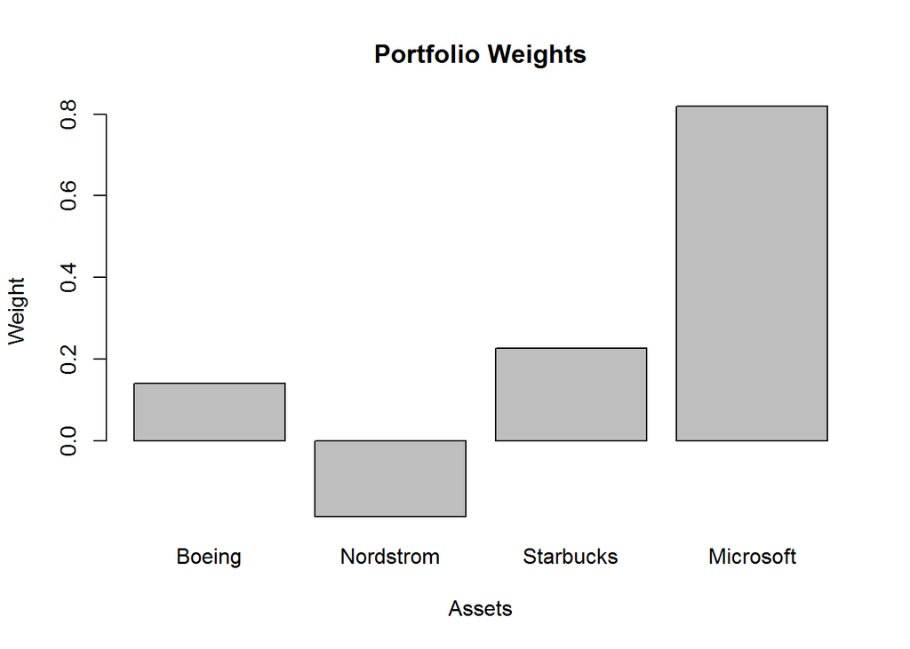

```r
plot(efficient_porfolio_short)
```

```r
# no short sales allowed
efficient_porfolio_no_short <- efficient_porfolio_short <- efficient.portfolio(er = mu_hat_month,
                                                target.return = mu_target,
                                                cov.mat = cov_mat_month,
                                                shorts = F)

efficient_porfolio_no_short
```

```
## Call:
## efficient.portfolio(er = mu_hat_month, cov.mat = cov_mat_month,
##     target.return = mu_target, shorts = F)
##
## Portfolio expected return:     0.04271183
## Portfolio standard deviation:  0.1006092
## Portfolio weights:
##    Boeing Nordstrom Starbucks Microsoft
##         0         0         0         1
```

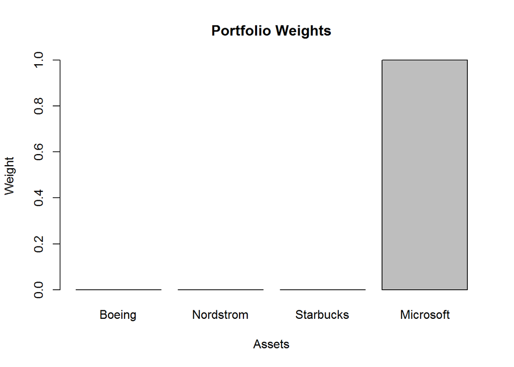

```r
plot(efficient_porfolio_no_short)
```

# Task 7 The efficient frontier

- Use the efficient.frontier() function to calculate the expected returns and standard deviation of the portfolios lying on the curve. Make a grid for $\alpha$=1,0.9,…,-1. Assign the result to efficient_frontier. Type args(efficient.frontier) to print the arguments of that function to the console. Choose the appropriate values for alpha.min and alpha.max.
- Make a plot of the efficient frontier curve via plot(). Set the colors of the dots to blue, the lwd argument to 2, and make sure that the stock names are displayed.

```r
# All data and CER parameters are preloaded in your workspace.  Type 'ls()' in the console to see them.

# The efficient frontier of risky assets
efficient_frontier <- efficient.frontier(er = mu_hat_month,
                                         cov.mat = cov_mat_month,
                                         nport = 21,
                                         alpha.min = -1,
                                         alpha.max = 1,
                                         shorts = T)

summary(efficient_frontier)
```

```
## Frontier portfolios' expected returns and standard deviations
##    port 1 port 2 port 3 port 4 port 5 port 6 port 7 port 8 port 9 port 10
## ER 0.0670 0.0645 0.0621 0.0597 0.0573 0.0548 0.0524 0.0500 0.0476  0.0451
## SD 0.1506 0.1442 0.1379 0.1317 0.1256 0.1195 0.1136 0.1077 0.1020  0.0965
##    port 11 port 12 port 13 port 14 port 15 port 16 port 17 port 18 port 19
## ER  0.0427  0.0403  0.0379  0.0354  0.0330  0.0306  0.0282  0.0257  0.0233
## SD  0.0911  0.0860  0.0811  0.0765  0.0724  0.0686  0.0654  0.0628  0.0609
##    port 20 port 21
## ER  0.0209  0.0185
## SD  0.0597  0.0593
##
## Portfolio weights:
##          Boeing Nordstrom Starbucks Microsoft
## port 1  -0.1755   -0.5937    0.4002    1.3690
## port 2  -0.1439   -0.5529    0.3828    1.3140
## port 3  -0.1123   -0.5120    0.3653    1.2590
## port 4  -0.0807   -0.4712    0.3479    1.2041
## port 5  -0.0492   -0.4303    0.3304    1.1491
## port 6  -0.0176   -0.3895    0.3130    1.0941
## port 7   0.0140   -0.3486    0.2955    1.0391
## port 8   0.0456   -0.3078    0.2781    0.9841
## port 9   0.0772   -0.2669    0.2606    0.9291
## port 10  0.1088   -0.2261    0.2432    0.8741
## port 11  0.1404   -0.1852    0.2257    0.8192
## port 12  0.1719   -0.1444    0.2083    0.7642
## port 13  0.2035   -0.1035    0.1908    0.7092
## port 14  0.2351   -0.0627    0.1734    0.6542
## port 15  0.2667   -0.0218    0.1559    0.5992
## port 16  0.2983    0.0190    0.1385    0.5442
## port 17  0.3299    0.0599    0.1210    0.4893
## port 18  0.3614    0.1007    0.1036    0.4343
## port 19  0.3930    0.1416    0.0861    0.3793
## port 20  0.4246    0.1824    0.0687    0.3243
## port 21  0.4562    0.2233    0.0512    0.2693
```

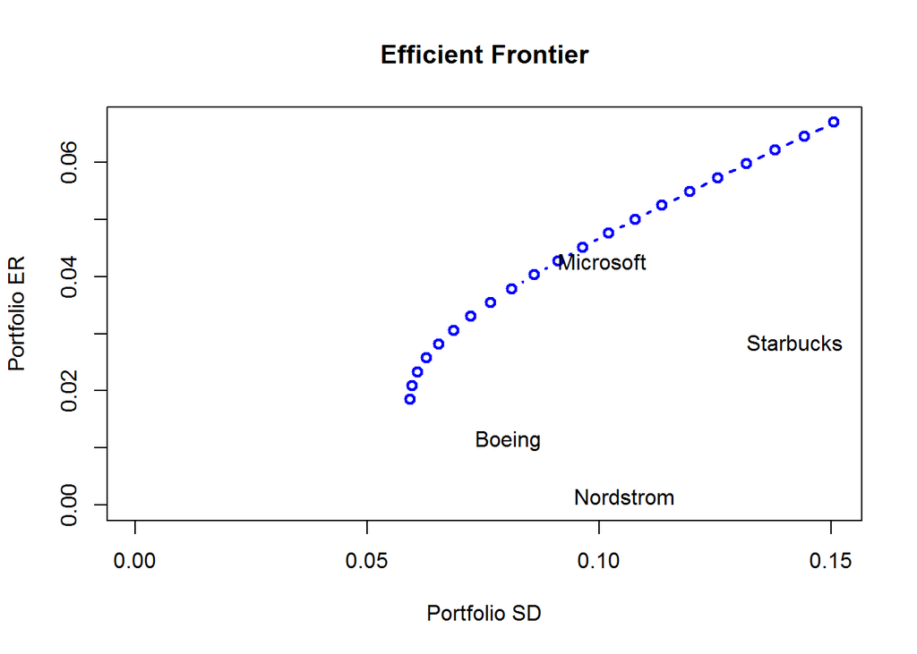

```r
# The plot
plot(efficient_frontier,plot.assets=T, col= "blue",lwd = 2)
```

# Task 8 The tangency portfolio

- Assign the monthly risk-free rate to t_bill_rate.
- Use the tangency.portfolio() function to calculate the efficient portfolio characteristics for both cases, that is, one where short sales is allowed, and one where short sales is not allowed. Assign the results to tangency_portfolio_short and tangency_portfolio_no_short.
- Study the plots that represent the weights of the stocks in both portfolios. The corresponding plot() functions are already provided.

```r
# All data and CER parameters are preloaded in your workspace.  Type 'ls()' in the console to see them.

# risk free rate
t_bill_rate <- 0.005

# Tangency portfolio short sales allowed
tangency_portfolio_short <- tangency.portfolio(er = mu_hat_month,
                                               cov.mat =cov_mat_month,
                                               risk.free = t_bill_rate,
                                               shorts = T)

summary(tangency_portfolio_short)
```

```
## Call:
## tangency.portfolio(er = mu_hat_month, cov.mat = cov_mat_month,
##     risk.free = t_bill_rate, shorts = T)
##
## Portfolio expected return:     0.05051316
## Portfolio standard deviation:  0.108985
## Portfolio weights:
##    Boeing Nordstrom Starbucks Microsoft
##    0.0387   -0.3166    0.2818    0.9960
```

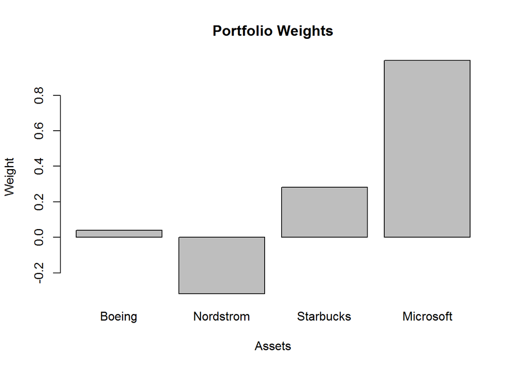

```r
#plot
plot(tangency_portfolio_short)
```

```r
# Tangency portfolio short sales not allowed
tangency_portfolio_no_short <- tangency.portfolio(er = mu_hat_month,
                                               cov.mat =cov_mat_month,
                                               risk.free = t_bill_rate,
                                               shorts = F)

summary(tangency_portfolio_no_short)
```

```
## Call:
## tangency.portfolio(er = mu_hat_month, cov.mat = cov_mat_month,
##     risk.free = t_bill_rate, shorts = F)
##
## Portfolio expected return:     0.03927075
## Portfolio standard deviation:  0.08594992
## Portfolio weights:
##    Boeing Nordstrom Starbucks Microsoft
##    0.0171    0.0000    0.2037    0.7792
```

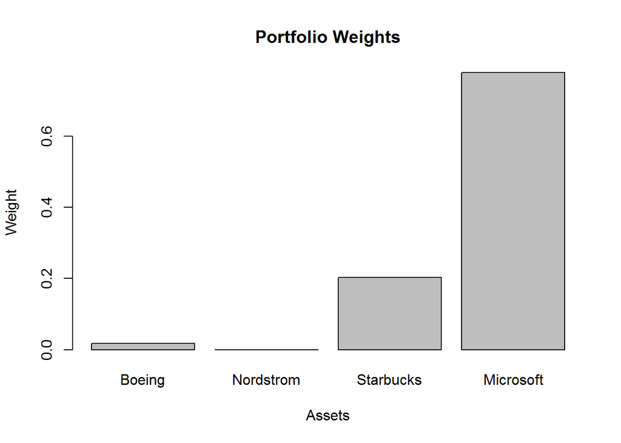

```r
#plot
plot(tangency_portfolio_no_short)
```